# Lab 12: Basic Data Visualization

Alison Fowler

12/2/2020

Intructions [here](https://cytoscape.org/cytoscape-tutorials/protocols/basic-data-visualization/#/)

### Intro

Cytoscape is an open source software platform for integrating, visualizing, and analyzing measurement data in the context of networks.

This tutorial presents a scenario of how expression and network data can be combined to tell a biological story and includes these concepts:

- Visualizing networks using expression data.
- Filtering networks based on expression data.
- Assessing expression data in the context of a biological network.

### Loading Network

To get started, install and launch the latest version of Cytoscape.

We will use NDEx to find a relevant network. In the Network Search interface in the Control Panel, select NDEx from the drop-down, and type in “GAL1 GAL4 GAL80”.

In the search results, find the galFiltered network with data. Click the Import network to Cytoscape icon to the left of the network name.

Mine looks like this (not like in the tutorial):

[figure not shown]

### Visualizing Expression Data on Networks

Probably the most common use of expression data in Cytoscape is to set the visual properties of the nodes (color, shape, border) in a network according to expression data. This creates a powerful visualization, portraying functional relation and experimental response at the same time. Here, we will show an example of doing this.

The data used in this example is from yeast, and represents an experiment of perturbations of the genes Gal1, Gal4, and Gal80, which are all yeast transcription factors.

For this tutorial, the experimental data was part of the Cytoscape session file you loaded earlier, and is visible in the Node Table.

You can select nodes in the network by Shift + Click and Drag or by Shift + clicking on multiple nodes. Selecting one or more nodes in the network will update the Node Table to show only the corresponding row(s).

We can now use the data to manipulate the visual properties of the network by mapping specific data columns to visual style properties:

- The gal80Rexp expression values will be mapped to node color; nodes with low expression will be colored blue, nodes with high expression will be colored red.
- Significance for expression values will be mapped to Node Border Width, so nodes with significant changes will appear with a thicker border.

### Set node fill color, default node color, node border width

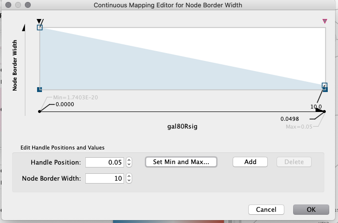

[figure not shown]

### Creating a Legend

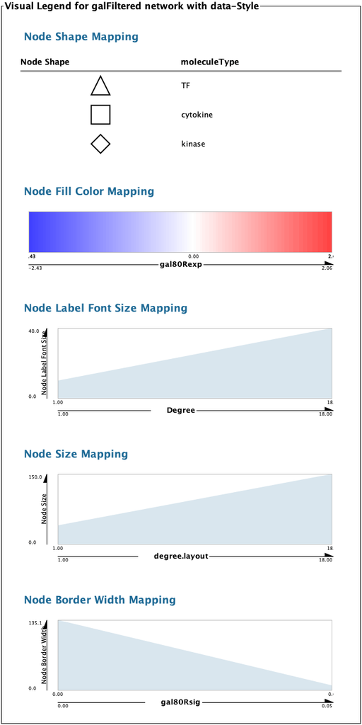

### Layouts

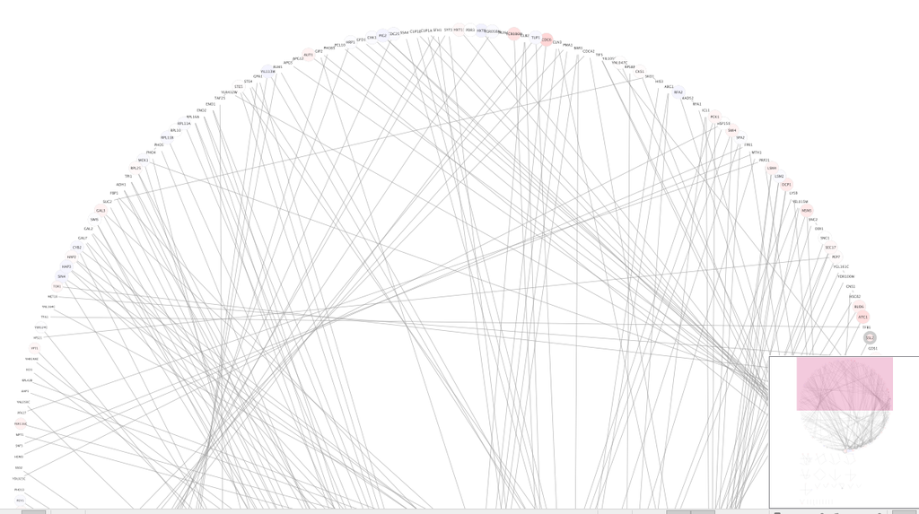

### Select Nodes

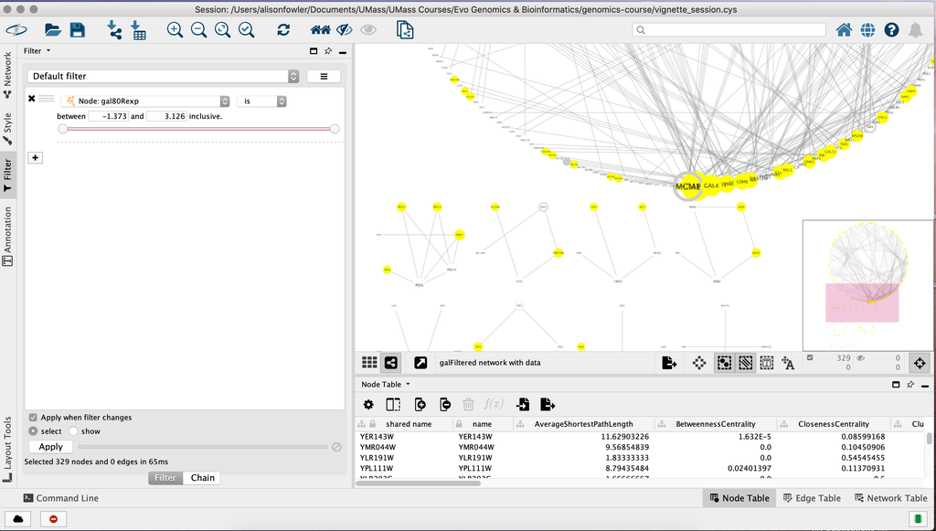

### Expand Selection and Create New Network

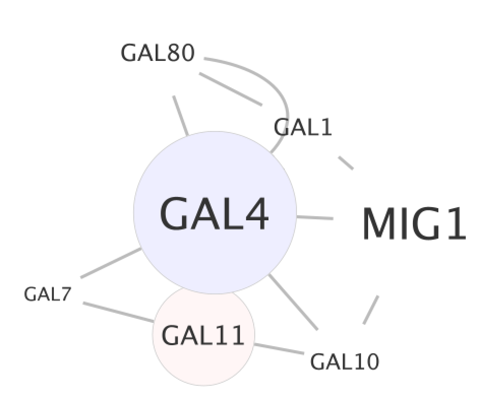

### Exploring Nodes

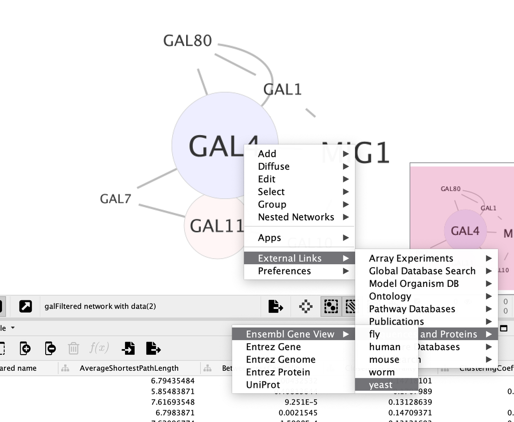

—>

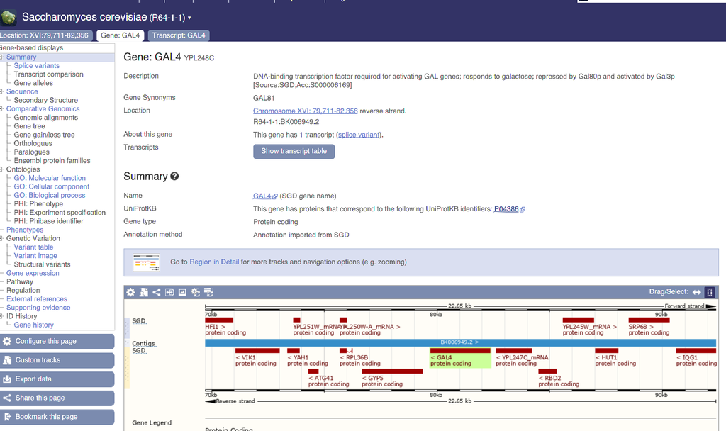

Putting all of this together, we see that the transcriptional activation activity of Gal4 is repressed by Gal80. So, repression of Gal80 increases the transcriptional activation activity of Gal4. Even though the expression of Gal4 itself did not change much, the Gal4 transcripts were much more likely to be active transcription factors when Gal80 was repressed. This explains why there is so much up-regulation in the vicinity of Gal4.

### Summary

Finally, we can now export this network as a publication-quality image….

### Saving Results

- As a session: File → Save, File → Save As…
- As an image: File → Export → Network to Image…
- To the web: File → Export → Network to Web Page… (Example)
- To a public repository: File → Export → Network to NDEx, or File → Export → Collection to NDEx
- As a graph format file: File → Export → Network to File.

Formats: * CX JSON * Cytoscape.js JSON * GraphML * PSI-MI * XGMML * SIF